# Home Credit Default Risk: Modeling

**Author:** Benjamin Hogan

## Introduction

This notebook develops a binary classification model to predict loan default risk for Home Credit Group applicants. The target variable `TARGET` equals 1 for applicants who experienced payment difficulties and 0 otherwise. The dataset is heavily imbalanced (~8% default rate), so we use **AUC-ROC** as our primary evaluation metric rather than accuracy.

The modeling workflow:

1. **Baseline benchmark** — majority class classifier and a naive logistic regression
2. **Candidate model comparison** — logistic regression variants, random forest, LightGBM
3. **Class imbalance handling** — SMOTE, upsampling, downsampling, and class weights
4. **Hyperparameter tuning** — randomized search on a 5K subsample with 3-fold CV
5. **Supplementary features** — bureau, previous application, and installment aggregations
6. **Final model** — retrain best configuration on full training data

## Data Loading & Preparation

We load `application_train.csv` and apply the full cleaning and feature-engineering pipeline from `data_preparation.py`. All parameters (e.g., EXT_SOURCE medians) are fitted from this data only.

```
Train shape:  (307511, 107)
Default rate: 0.0807
```

## Section 1: Baseline Benchmark

Before building any real model, we need to know what "doing nothing" looks like. Two baselines are established:

1. **Majority class classifier** — always predicts 0 (no default).
2. **Simple logistic regression** — trained only on the three `EXT_SOURCE` scores.

All estimates use **3-fold stratified cross-validation**.

| Model | Accuracy | AUC-ROC |
| --- | --- | --- |
| Majority class classifier | 0.9193 | 0.5000 |
| Logistic Reg. (EXT_SOURCE only) | 0.9192 | 0.7177 |

The majority class classifier achieves ~92% accuracy but an AUC of exactly 0.5 — equivalent to random guessing. The simple logistic regression using only the three external credit scores already provides meaningful lift.

## Section 2: Candidate Model Comparison

We compare four candidate models using the full feature set. All evaluated with **3-fold stratified CV**.

| Model | Mean AUC | Std AUC |
| --- | --- | --- |
| LR — full features | 0.7454 | 0.0022 |
| LR — engineered features | 0.7304 | 0.0029 |
| Random Forest | 0.7276 | 0.0013 |
| LightGBM | 0.7664 | 0.0016 |
| LightGBM | 0.7664 | 0.0016 |

## Section 3: Addressing Class Imbalance

The training data has an ~8% default rate. We test five strategies using LightGBM on a **10,000-row stratified subsample**.

| Strategy | Mean AUC | Std AUC |
| --- | --- | --- |
| No adjustment | 0.6956 | 0.0037 |
| Class weights (scale_pos_weight) | 0.6903 | 0.0008 |
| Random oversampling | 0.6915 | 0.0059 |
| Random undersampling | 0.7097 | 0.0034 |
| SMOTE | 0.7061 | 0.0035 |

**Best strategy:** Random undersampling

SMOTE is applied inside the cross-validation loop via `ImbPipeline` to prevent data leakage.

## Section 4: Hyperparameter Tuning

We tune LightGBM using **randomized search** (20 iterations, 3-fold CV) on a **5,000-row subsample**.

**Best CV AUC (5K subsample, 3-fold):** 0.6861

| Parameter | Value |
| --- | --- |
| `colsample_bytree` | 0.7139 |
| `learning_rate` | 0.0174 |
| `max_depth` | 3 |
| `min_child_samples` | 11 |
| `n_estimators` | 229 |
| `num_leaves` | 73 |
| `reg_alpha` | 0.0331 |
| `reg_lambda` | 0.3451 |
| `subsample` | 0.8537 |

**Final model CV AUC (full data, 3-fold):** 0.7477 ± 0.0026

Final model trained on full dataset.

## Section 5: Supplementary Features

### 5a–5b: Core & Additional Tables

Bureau aggregated: (305811, 16) | Previous app aggregated: (338857, 13) | Installments aggregated: (339587, 13)

POS CASH aggregated: (337252, 7) | Credit card aggregated: (103558, 10)

Shape without supplementary: (307511, 107) → Shape with supplementary: (307511, 161) (New features added: 54)

[output not shown]

### 5c–5d: AUC With vs. Without Supplementary Features

We retrain the tuned LightGBM model on both feature sets and compare 3-fold CV AUC.

| Feature Set | Mean AUC | Std AUC |
| --- | --- | --- |
| Without supplementary features | 0.7477 | 0.0026 |
| With supplementary features | 0.7592 | 0.0024 |

Final model retrained with supplementary features.

## Section 6: Summary & Conclusions

### Model Comparison Summary

| Stage | Mean AUC |
| --- | --- |
| Candidate — LightGBM (default params) | 0.7664 |
| Tuned LightGBM + supplementary features | 0.7592 |
| Tuned LightGBM (app features only) | 0.7477 |
| Candidate — LR (full features) | 0.7454 |
| Candidate — LR (engineered features) | 0.7304 |
| Candidate — Random Forest | 0.7276 |
| Baseline — LR (EXT_SOURCE only) | 0.7177 |
| Imbalance — Best strategy (LightGBM) | 0.7097 |
| Baseline — Majority class classifier | 0.5000 |

### Top 25 Feature Importances

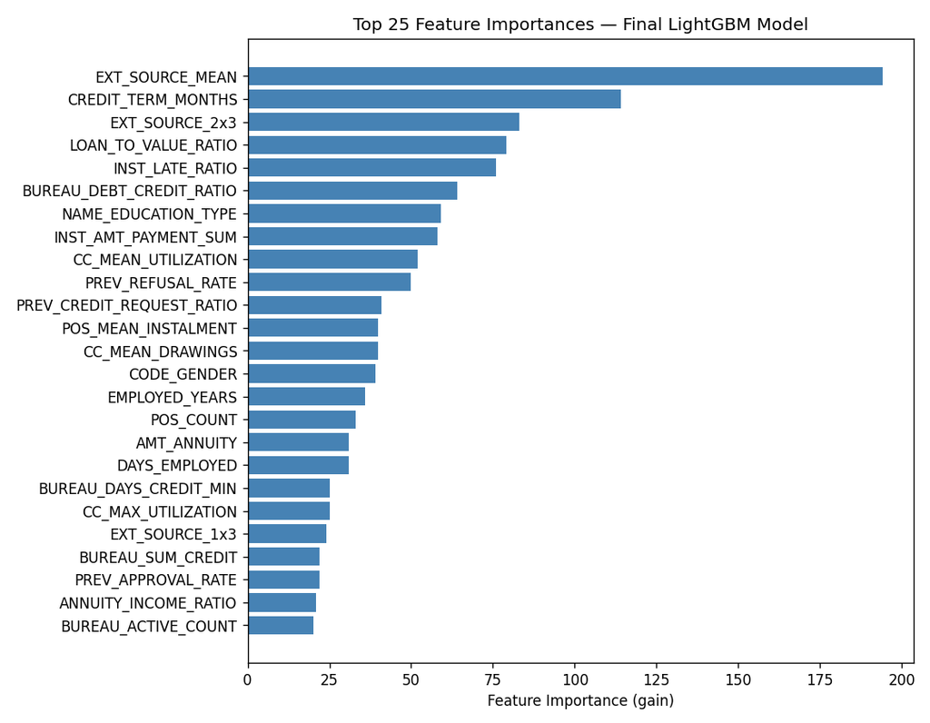

### Business Implications

The final model produces predicted probabilities that can be used to rank applicants by default risk. The model substantially outperforms the majority class benchmark, meaning Home Credit can more confidently extend credit to lower-risk applicants with limited credit histories — directly addressing the stated business problem.

## Section 7: Kaggle Test Set Submission

Predictions generated: **48,744**

Mean predicted probability: 0.4173 | Min: 0.0781 | Max: 0.8533

Submission saved to: `C:\Users\benjo\Documents\Grad School\IS 6850 Capstone\home-credit-default-risk\submission.csv` — Rows: 48,744

| SK_ID_CURR | TARGET (predicted prob.) |
| --- | --- |
| 100001 | 0.398630 |
| 100005 | 0.669889 |
| 100013 | 0.218052 |
| 100028 | 0.346309 |
| 100038 | 0.627147 |

## Kaggle Submission Result

The final submission was evaluated on the Kaggle public leaderboard for the [Home Credit Default Risk](https://www.kaggle.com/c/home-credit-default-risk) competition.

| Metric | Score |
| --- | --- |
| Public Leaderboard AUC-ROC | 0.74718 |